# ML_Course_project

EllieYin

11/29/2019

# Introduction

This project utilizes the Weight Lifting Exercises dataset to investigate “how (well)” an activity was performed by the wearer. Six young health participants were asked to perform one set of 10 repetitions of the Unilateral Dumbbell Biceps Curl in five different fashions: exactly according to the specification (Class A), throwing the elbows to the front (Class B), lifting the dumbbell only halfway (Class C), lowering the dumbbell only halfway (Class D) and throwing the hips to the front (Class E). Data from accelerometers on the belt, forearm, arm, and dumbell of 6 participants will be used for training.

# Set up

## Import the datasets

```r
# Download and read the training and test data
training <- read.csv("https://d396qusza40orc.cloudfront.net/predmachlearn/pml-training.csv")
test <- read.csv("https://d396qusza40orc.cloudfront.net/predmachlearn/pml-testing.csv")

# Summarize the number of observations in each class
training$classe <- as.factor(training$classe)
table(training$classe)
```

```
##
##    A    B    C    D    E
## 5580 3797 3422 3216 3607
```

```r
# Among the 160 variables, check how many of them are "near zero" variance predictors
nav <- nearZeroVar(training, saveMetrics = TRUE)
# Remove the ones "near zero"
training <- training[, !nav$nzv]

# Also, remove the first 5 columns
training <- training[, -c(1:5)]

# remove columns with NA value greater than 90% of the samples
percent_na <- apply(training,2, function(x)sum(is.na(x))/nrow(training))
remove_list <- names(percent_na[percent_na>0.9])

training <- training[, !colnames(training) %in% remove_list]

# Do the same cleaning for test data
test <- test[, !nav$nzv]
test <- test[, -c(1:5)]
test <- test[, !colnames(test) %in% remove_list]
```

# Training

Random forest, decision tree and boosting with trees will be tested and compared.

First, perform partition - split the training data into training and validation. We will use the training data to train the model and use the validation data to choose the best performed model and calcualte the out of sample error.

```r
# Partition the dataset into training and validation
inTrain<-createDataPartition(y=training$classe, p=0.7, list=FALSE)
training_par<-training[inTrain,]
validation_par<-training[-inTrain,]
```

Check the correlation relationship between predictors.

```r
# Perform correlation between params
M <- abs(cor(training[,-54]))
diag(M) <- 0 #set the self -correlation value to 0
# List the ones with correlation coefficient over 0.8
which(M>0.8, arr.ind =T)
```

```
##                  row col
## yaw_belt           4   2
## total_accel_belt   5   2
## accel_belt_y      10   2
## accel_belt_z      11   2
## accel_belt_x       9   3
## magnet_belt_x     12   3
## roll_belt          2   4
## roll_belt          2   5
## accel_belt_y      10   5
## accel_belt_z      11   5
## pitch_belt         3   9
## magnet_belt_x     12   9
## roll_belt          2  10
## total_accel_belt   5  10
## accel_belt_z      11  10
## roll_belt          2  11
## total_accel_belt   5  11
## accel_belt_y      10  11
## pitch_belt         3  12
## accel_belt_x       9  12
## gyros_arm_y       20  19
## gyros_arm_x       19  20
## magnet_arm_x      25  22
## accel_arm_x       22  25
## magnet_arm_z      27  26
## magnet_arm_y      26  27
## accel_dumbbell_x  35  29
## accel_dumbbell_z  37  30
## gyros_dumbbell_z  34  32
## gyros_forearm_z   47  32
## gyros_dumbbell_x  32  34
## gyros_forearm_z   47  34
## pitch_dumbbell    29  35
## yaw_dumbbell      30  37
## gyros_forearm_z   47  46
## gyros_dumbbell_x  32  47
## gyros_dumbbell_z  34  47
## gyros_forearm_y   46  47
```

## Random forest

```r
# we will use 5 fold cross validation
trControl <- trainControl(method="cv", number=5)
# Model fit
set.seed(1)
fit1 <- train(classe ~., data = training_par, method = "rf", trControl=trControl)
# Check the accuracy
con1 <- confusionMatrix(validation_par$classe, predict(fit1, validation_par))
con1
```

```
## Confusion Matrix and Statistics
##
##           Reference
## Prediction    A    B    C    D    E
##          A 1674    0    0    0    0
##          B    5 1134    0    0    0
##          C    0    1 1025    0    0
##          D    0    0    2  962    0
##          E    0    0    0    5 1077
##
## Overall Statistics
##
##                Accuracy : 0.9978
##                  95% CI : (0.9962, 0.9988)
##     No Information Rate : 0.2853
##     P-Value [Acc > NIR] : < 2.2e-16
##
##                   Kappa : 0.9972
##
##  Mcnemar's Test P-Value : NA
##
## Statistics by Class:
##
##                      Class: A Class: B Class: C Class: D Class: E
## Sensitivity            0.9970   0.9991   0.9981   0.9948   1.0000
## Specificity            1.0000   0.9989   0.9998   0.9996   0.9990
## Pos Pred Value         1.0000   0.9956   0.9990   0.9979   0.9954
## Neg Pred Value         0.9988   0.9998   0.9996   0.9990   1.0000
## Prevalence             0.2853   0.1929   0.1745   0.1643   0.1830
## Detection Rate         0.2845   0.1927   0.1742   0.1635   0.1830
## Detection Prevalence   0.2845   0.1935   0.1743   0.1638   0.1839
## Balanced Accuracy      0.9985   0.9990   0.9989   0.9972   0.9995
```

- Random forest modeling showed an accuracy of 0.997791.

## Decision trees

[figure not shown]

```r
#training
set.seed(2)
fit2 <- train(classe ~ ., method = "rpart", data=training_par, trControl=trControl)
fancyRpartPlot(fit2$finalModel)
```

```r
#predict
con2 <- confusionMatrix(validation_par$classe, predict(fit2, validation_par))
con2
```

```
## Confusion Matrix and Statistics
##
##           Reference
## Prediction    A    B    C    D    E
##          A 1502   31  135    0    6
##          B  474  366  299    0    0
##          C  176   41  809    0    0
##          D  337  119  455    0   53
##          E   62  197  175    0  648
##
## Overall Statistics
##
##                Accuracy : 0.565
##                  95% CI : (0.5522, 0.5777)
##     No Information Rate : 0.4335
##     P-Value [Acc > NIR] : < 2.2e-16
##
##                   Kappa : 0.4382
##
##  Mcnemar's Test P-Value : < 2.2e-16
##
## Statistics by Class:
##
##                      Class: A Class: B Class: C Class: D Class: E
## Sensitivity            0.5888  0.48541   0.4319       NA   0.9165
## Specificity            0.9484  0.84935   0.9459   0.8362   0.9162
## Pos Pred Value         0.8973  0.32133   0.7885       NA   0.5989
## Neg Pred Value         0.7509  0.91825   0.7810       NA   0.9877
## Prevalence             0.4335  0.12812   0.3183   0.0000   0.1201
## Detection Rate         0.2552  0.06219   0.1375   0.0000   0.1101
## Detection Prevalence   0.2845  0.19354   0.1743   0.1638   0.1839
## Balanced Accuracy      0.7686  0.66738   0.6889       NA   0.9164
```

- Decision trees modeling showed an accuracy of 0.5649958.

## Boosting

```r
set.seed(3)
#training
fit3 <- train(classe ~ ., method = "gbm", data=training_par, trControl=trControl)
#predict
con3 <- confusionMatrix(validation_par$classe, predict(fit3, validation_par))
```

- Boosting modeling showed an accuracy of 0.9850467.

## Compare three models

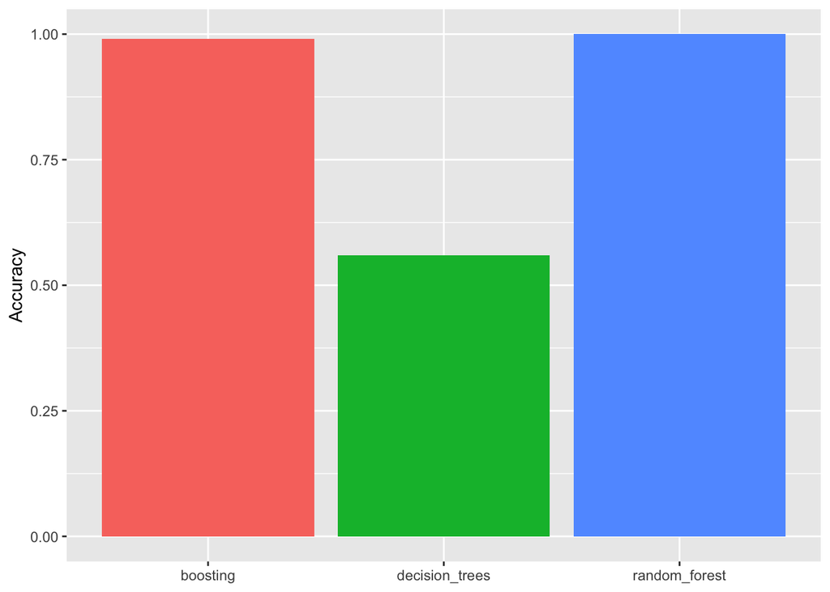

```r
accuracy <- data.frame(rbind(c("random_forest",con1$overall[1]), c("decision_trees", con2$overall[1]), c("boosting",con3$overall[1])))
accuracy$Accuracy <- as.numeric(as.character(accuracy$Accuracy))
ggplot(accuracy, aes(x=V1, y=round(Accuracy, digits = 2), fill=V1)) + geom_bar(stat="identity") + ylab("Accuracy") + theme(legend.position = "none",axis.title.x=element_blank())
```

- Random forest gave the best accuracy and will be used to predict the test data.

# Prediction

Use the random forest model to predict the test data.

```r
predict(fit1, test)
```

```
##  [1] B A B A A E D B A A B C B A E E A B B B
## Levels: A B C D E
```